# Satellite day @FBN: ggplot2-Plotting Anything

Author

Anja Eggert

Published

March 5, 2025

# R Libraries

Please note that the package `ggplot2` is included in the tidy universe:

```r
library(tidyverse)     # tidy universe
library(viridis)       # colour scales
library(patchwork)     # combine plots

library(agridat)       # agricultural data sets
```

# Data sets

You can use data from the `agridat` R package or your own data. But also other packages come with data sets. You can see the list of pre-loaded data, type the function `data()`:

```r
data()
?agridat # list all datasets with keywords
```

```
starte den http Server für die Hilfe fertig
```

```r
data("crampton.pig")

head(crampton.pig)
```

```
  treatment rep weight1 feed weight2
1        T1  R1      30  674     195
2        T1  R2      21  628     177
3        T1  R3      21  661     180
4        T1  R4      33  694     200
5        T1  R5      27  713     197
6        T1  R6      24  585     170
```

You could also type this:

```r
dat <- agridat::crampton.pig
```

# Some data wrangling

I like to use the tidy way of data processing. Therefore I suggest to convert the data table into a tibble. We also convert columns into factors.

```r
dat <- as_tibble(dat) |>
  mutate_at(vars(treatment,
                 rep), ~as.factor(.))

dat
```

```
# A tibble: 50 × 5
   treatment rep   weight1  feed weight2
   <fct>     <fct>   <int> <int>   <int>
 1 T1        R1         30   674     195
 2 T1        R2         21   628     177
 3 T1        R3         21   661     180
 4 T1        R4         33   694     200
 5 T1        R5         27   713     197
 6 T1        R6         24   585     170
 7 T1        R7         20   575     150
 8 T1        R8         29   638     180
 9 T1        R9         28   632     192
10 T1        R10        26   637     184
# ℹ 40 more rows
```

# Building simple ggplots

## Empty plot

This only creates an empty plot, without any layers.

```r
ggplot(data = dat,
       aes(x = feed, y = weight2))
```

You can run the code without typing “data =”. It is just shorter.

```r
ggplot(dat,
       aes(x = feed, y = weight2))
```

Or you can also pipe the data into ggplot:

```r
dat |>
  ggplot(aes(x = feed, y = weight2))
```

## Simple scatter plot

Now we add `geom_point()` to create a scatter plot. The components of a ggplot are combined with `+`.

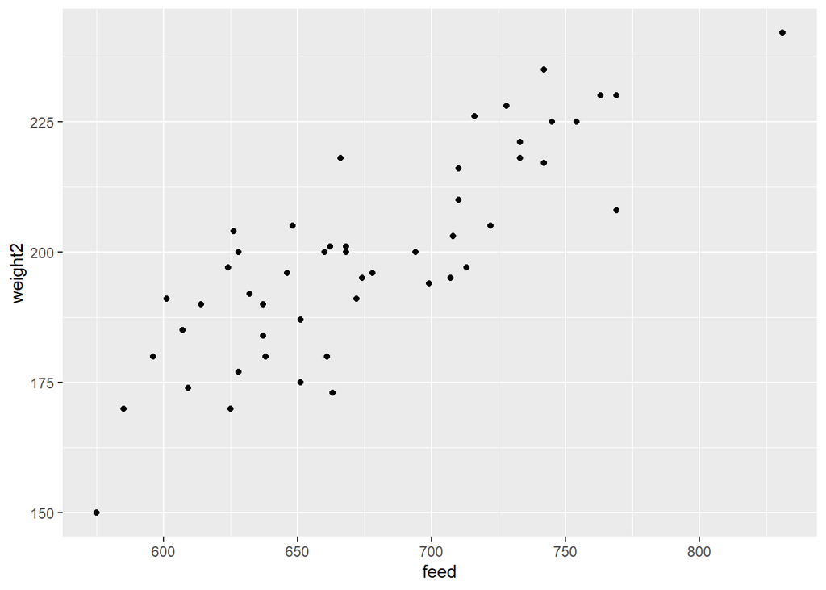

```r
dat |>
  ggplot(aes(x = feed, y = weight2)) +
  geom_point()
```

`geom_point()` is a shortcut. Behind the scenes it calls the `layer()` function to create a new layer:

```r
layer(
  mapping = NULL,
  data = NULL,
  geom = "point", geom_params = list(),
  stat = "identity", stat_params = list(),
  position = "identity"
)
```

## Add more layers

Combine a scatter and a line plot and choose a theme of your choice. Please recognize that the order of the layers matters:

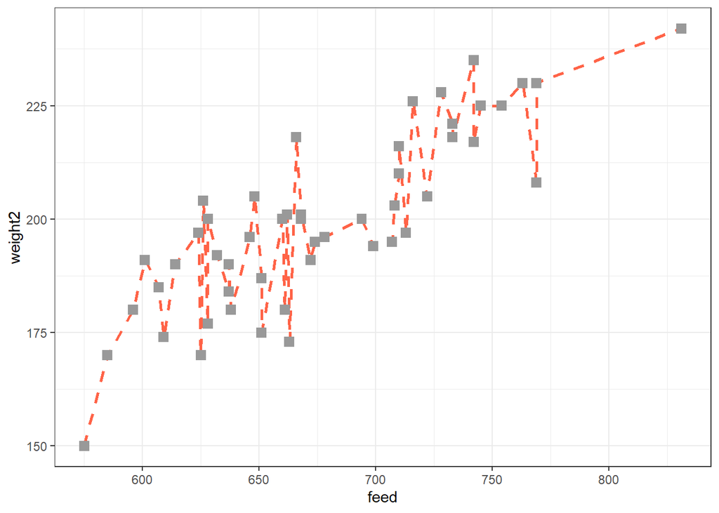

```r
dat |>
  ggplot(aes(x = feed, y = weight2)) +
  geom_line(colour = "tomato", linewidth = 1, linetype = "dashed") +
  geom_point(size = 3, colour = "grey60", shape = 15) +
  theme_bw()
```

Do you see the difference?

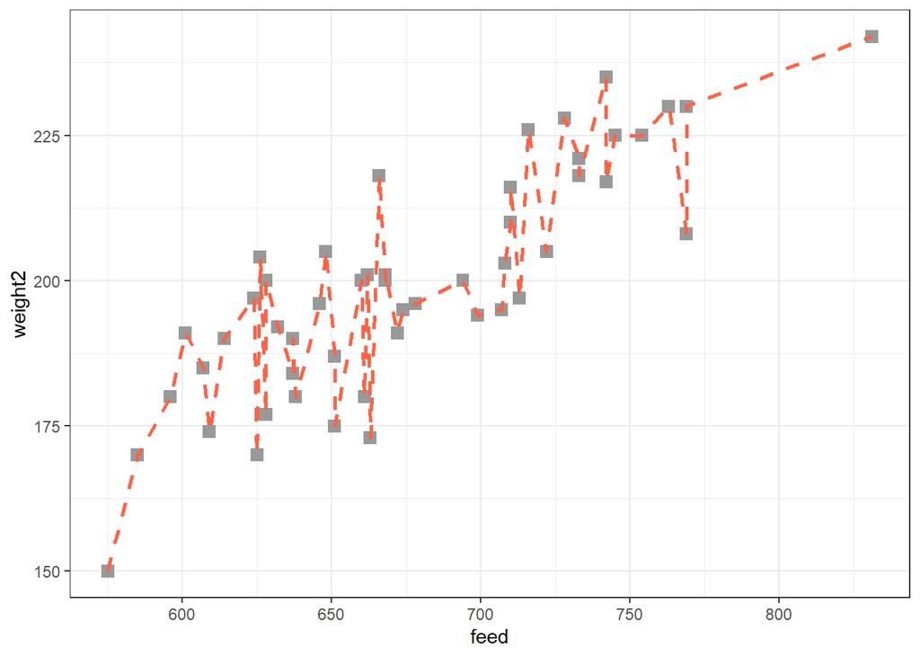

```r
dat |>
  ggplot(aes(x = feed, y = weight2)) +
  geom_point(size = 3, colour = "grey60", shape = 15) +
  geom_line(colour = "tomato", linewidth = 1, linetype = "dashed") +
  theme_bw()
```

## TASK 1

1. The linetype, linewidth, size, and shape aesthetics modify the appearance of lines and points. Change linetype, shape of the points and/or colour.
2. In the scatter plot, choose `shape = 16` and `shape = 21`. Colour the points using `col =` and `fill =`. What do you recognize?
3. Colour the points depending on another variable in the data set. What is the difference between a continuous and discrete variable?
4. Label the x-axis and y-axis using `labs =`. Use `?labs` and use the help page.

HINT 1:

```r
dat |>
  ggplot(aes(x = feed, y = weight2)) +
  geom_line(colour = "___", linewidth = 1, linetype = "___") +
  geom_point(size = 2, shape = ___) +
  theme_classic()
```

HINT 2:

```r
dat |>
  ggplot(aes(x = feed, y = weight2)) +
  geom_point(size = 2, shape = ___, fill = "___", col = "___") +
  theme_classic()
```

HINT 3:

```r
dat |>
  ggplot(aes(x = feed, y = weight2, col = ___)) +
  geom_point(size = 3) +
  theme_bw()
```

HINT 4:

```r
dat |>
  ggplot(aes(x = feed, y = weight2, col = treatment)) +
  geom_line(colour = "grey80", linewidth = 0.5, linetype = "solid") +
  geom_point(size = 3) +
  labs(___) +
  theme_bw()
```

# More complex ggplots

## The `group` aesthetic

The `group` aesthetic controls how data points are connected or grouped for certain geometries (`geom_`). When you use:

`ggplot(aes(x = feed, y = weight2, group = treatment))`

it means that observations sharing the same value of `treatment` are treated as a group in the visualization. The effect of this depends on the type of geom used:

When `group = treatment` is specified in a line plot, it ensures that each level of `treatment` gets its own separate line.

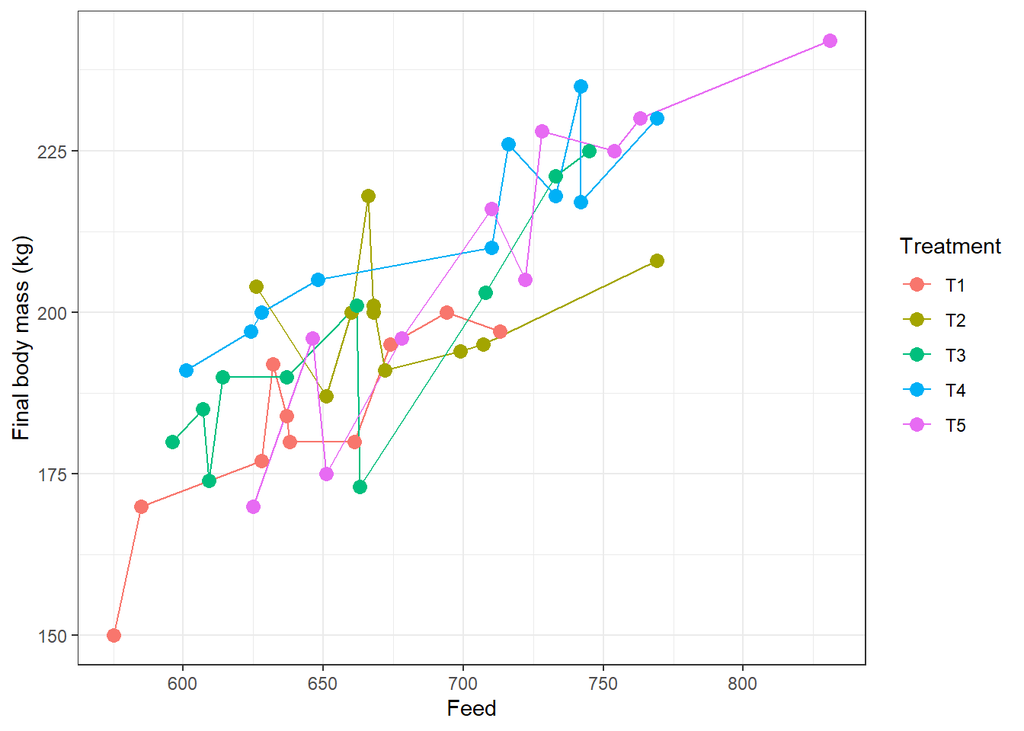

```r
dat |>
  ggplot(aes(x = feed, y = weight2, group = treatment, col = treatment)) +
  geom_line(linewidth = 0.5, linetype = "solid") +
  geom_point(size = 3) +
  labs(x = "Feed",
       y = "Final body mass (kg)",
       col = "Treatment") +
  theme_bw()
```

## Statistical transformations

Add a statistics layer, here `lm` function to smooth the data.

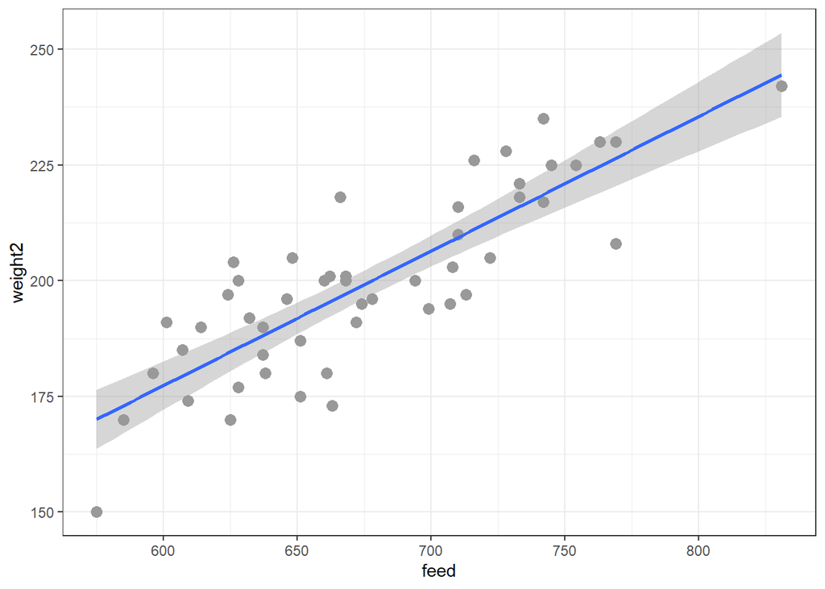

```r
dat |>
  ggplot(aes(x = feed, y = weight2)) +
  geom_point(size = 3, colour = "grey60") +
  geom_smooth(method = "lm") +
  theme_bw()
```

For scatter plots, group usually is not needed because each point is independent. But if used in combination with `geom_smooth()`, it affects how trend lines are drawn.

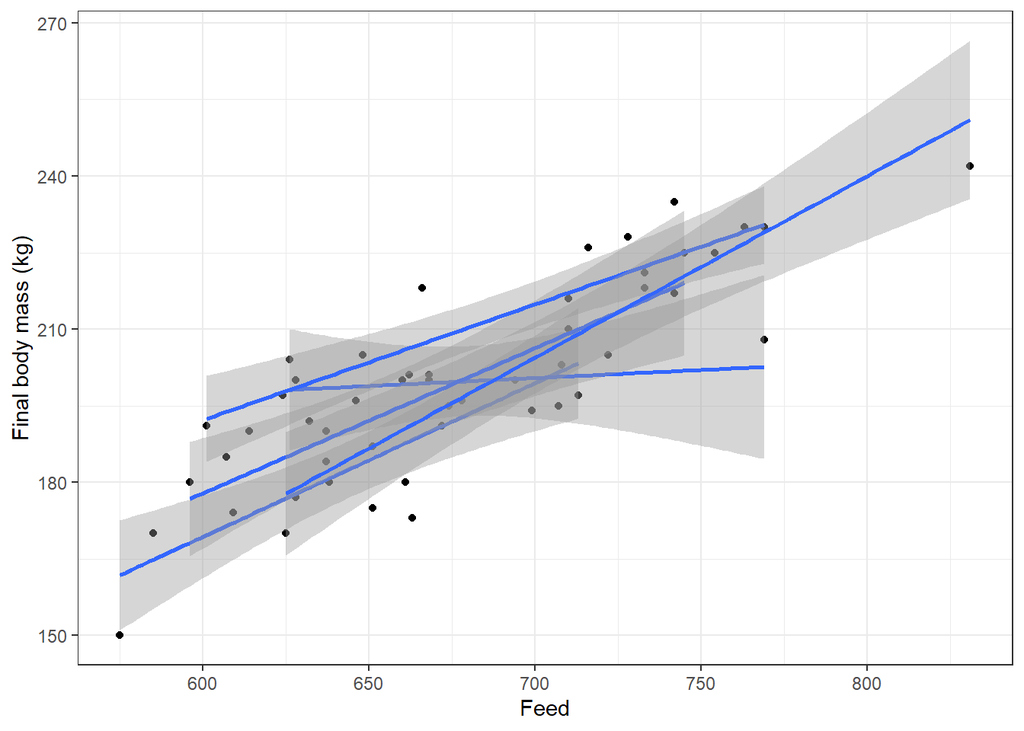

```r
dat |>
  ggplot(aes(x = feed, y = weight2, group = treatment)) +
  geom_point() +
  geom_smooth(method = "lm") +
  labs(x = "Feed",
       y = "Final body mass (kg)",
       col = "Treatment") +
  theme_bw()
```

## Jittering

Jittering is useful when data points overlap too much, making it hard to see individual observations. Instead of plotting points exactly at their values, jittering adds a small random variation, helping to reduce overplotting and make patterns more visible.

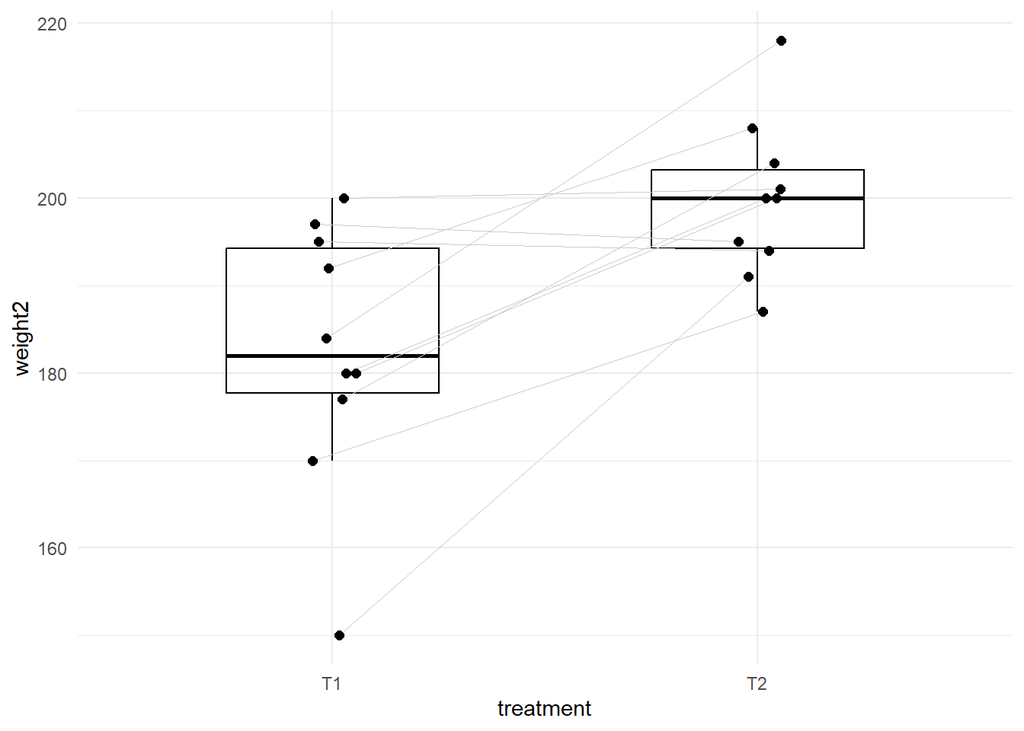

```r
dat |>
  dplyr::filter(treatment %in% c("T1", "T2")) |>
  mutate(jit = jitter(as.numeric(treatment), 0.3)) |>
  ggplot(aes(y = weight2)) +
  geom_boxplot(aes(x = treatment),
               col = "black", fill = NA,
               outlier.shape = NA, width=0.5,
               position = position_dodge(0.5)) +
  geom_line(aes(x = jit, group = rep),
            col = "grey80", linewidth = 0.2) +
  geom_point(aes(x = jit), size = 2) +
  theme_minimal()
```

## TASK 2

1. Apply a `group` aesthetic in a line plot and compare the result with a plot not using the `group` aesthetic statement. Colour the individual lines differently.
2. Add a statistics layer to a scatter plot. Add a loess function with and without the confidence interval.
3. Create a plot with jittering. Use `alpha =` to define transparency to the points.

HINT 1:

```r
dat |>
  ggplot(aes(x = feed, y = weight2, group = ___)) +
  geom_line(linewidth = 0.5, linetype = "solid") +
  geom_point(size = 3) +
  labs(x = "Feed",
       y = "Final body mass (kg)",
       col = "Treatment") +
  theme_bw()
```

HINT 2:

```r
dat |>
  ggplot(aes(x = feed, y = weight2)) +
  geom_point(size = 3, colour = "grey60") +
  geom_smooth(___) +
  theme_bw()
```

HINT 3:

```r
dat |>
  dplyr::filter(treatment %in% c("T1", "T2")) |>
  mutate(jit = jitter(___)) |>
  ggplot(aes(y = weight2)) +
  geom_boxplot(aes(x = treatment),
               col = "black", fill = NA,
               outlier.shape = NA, width=0.5,
               position = position_dodge(0.5)) +
  geom_line(aes(x = jit, group = rep),
            col = "grey80", linewidth = 0.2) +
  geom_point(aes(x = jit,
             size = 2, alpha = ___))
```

# Scales

Scales control how data is mapped to aesthetics (e.g., x, y, color, size). Each type of data: continuous, discrete, and date/time, requires the right scale function to properly represent it.

## Continuous scales

Use a colour scale from the `viridis` package:

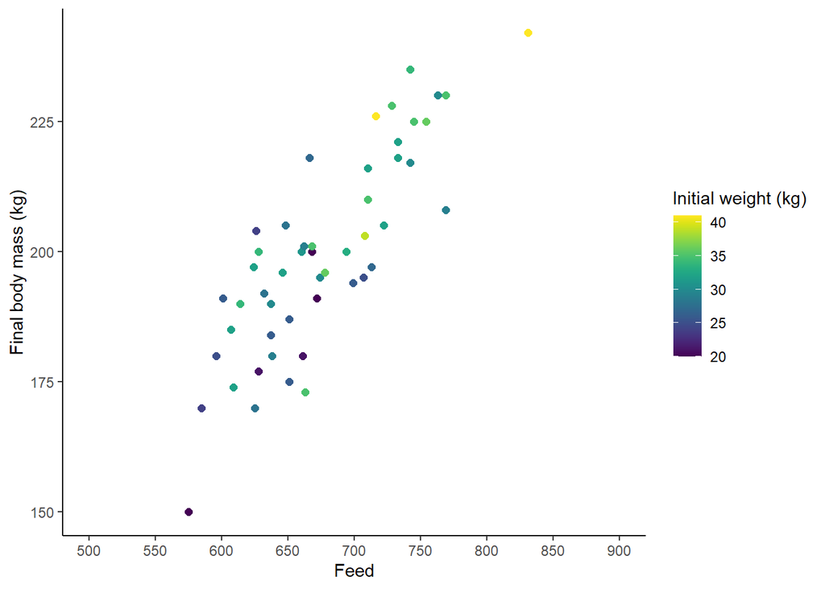

```r
dat |>
  ggplot(aes(x = feed, y = weight2, col = weight1)) +
  geom_point(size = 2) +
  scale_x_continuous(limits=c(500, 900),
                     breaks = seq(500,900,50)) +
  scale_colour_viridis(discrete = FALSE) +
  labs(x = "Feed",
       y = "Final body mass (kg)",
       col = "Initial weight (kg)") +
  theme_classic()
```

## Discrete scales

Use a colour scale from the `viridis` package:

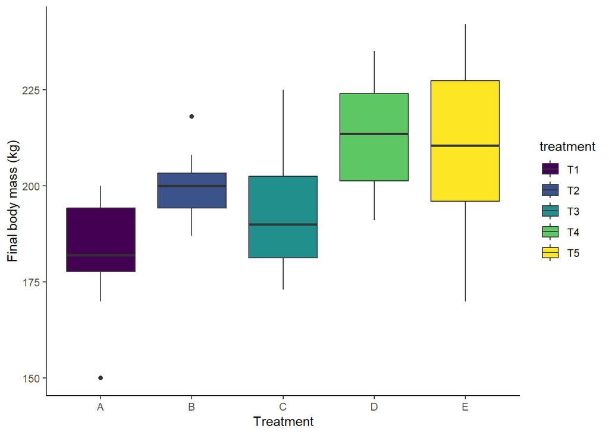

```r
dat |>
  ggplot(aes(x = treatment, y = weight2, fill = treatment)) +
  geom_boxplot() +
  scale_x_discrete(labels = c("A", "B", "C", "D", "E")) +
  scale_fill_viridis(discrete = TRUE) +
  labs(x = "Treatment",
       y = "Final body mass (kg)") +
  theme_classic()
```

You can define your manual scale:

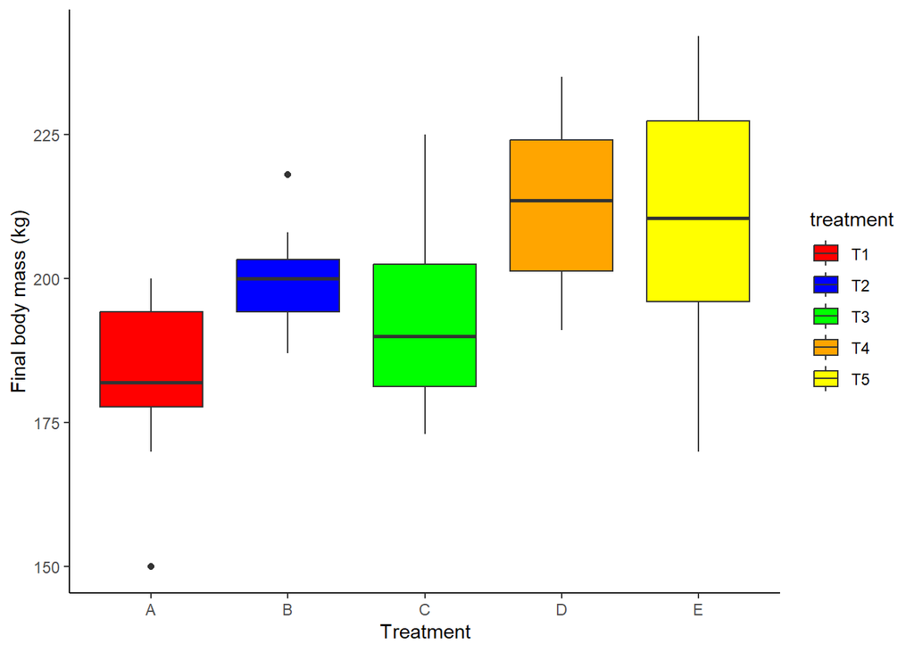

```r
dat |>
  ggplot(aes(x = treatment, y = weight2, fill = treatment)) +
  geom_boxplot() +
  scale_x_discrete(labels = c("A", "B", "C", "D", "E")) +
  scale_fill_manual(values = c("red",
                               "blue",
                               "green",
                               "orange",
                               "yellow")) +
  labs(x = "Treatment",
       y = "Final body mass (kg)") +
  theme_classic()
```

## Dates and times

This is a data set of daily air quality measurements in New York, May to September 1973.

```r
air <- data("airquality")

air <- as_tibble(airquality) |>
   mutate(
    Month = str_pad(Month, width = 2, side = "left", pad = "0"),
    Day = str_pad(Day, width = 2, side = "left", pad = "0"),
    Date = ymd(paste(1973, Month, Day, sep = "-"))
  )
```

We plot the data and add a box and some text.

In the theme, the size is defined in pts. So here 15, means 15 pts. In geom_text, the size is defined in mm, so it’s 15 mm. What is the relation between pts and mm or in? If we want exactly the same size for the title and the text in the plot, we can apply this conversion:

```r
# from pt to mm : mm = pt / .pt -> 15 / 2.845276 = 5.27
ggplot2::.pt
```

```
[1] 2.845276
```

If the date labels are shown in German, we can change this. Set Locale to English Use the Sys.setlocale() function to set the locale for the language you want.

```r
# Sys.setlocale("LC_TIME", "English_United States.UTF-8")
```

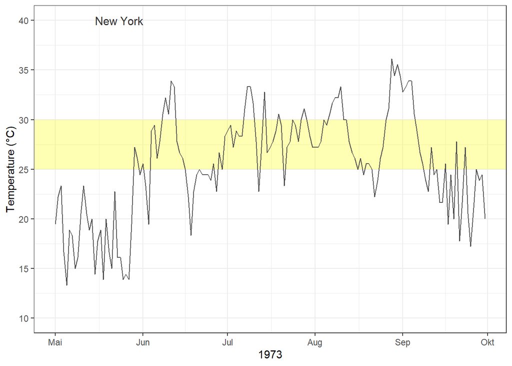

```r
rect <- data.frame(xmin=as.Date(-Inf), xmax=as.Date(Inf), ymin=25, ymax=30)

air |>
  ggplot(aes(x = Date, y= (Temp - 32)/(9/5))) +
  geom_rect(data=rect,
            aes(xmin=xmin, xmax=xmax, ymin=ymin, ymax=ymax),
            fill="yellow", alpha=0.3, inherit.aes = FALSE) +
  geom_line(colour="grey30") +
  scale_x_date(date_breaks = "1 month",
               date_labels = "%b",
               limits=c(as.Date("1973-05-01"), as.Date("1973-09-30"))) +
  scale_y_continuous(limits=c(10,40),
                     breaks=seq(10, 40, by = 5)) +
  labs(x = "1973",
       y = "Temperature (°C)") +
  annotate("text", x = as.Date('1973-05-15'), y = 40,
           label = "New York",
           size = 4, hjust = 0, colour = "grey20") +
  theme_bw()
```

## TASK 3

1. Make a scatter plot with coloured points and a red border.
2. Modify the date-scale of your plot for better readability. Show full month name instead of abbreviation.

Hint 1:

```r
dat |>
  ggplot(aes(x = feed, y = weight2, fill = weight1)) +
  geom_point(size = 2, ___) +
  scale_x_continuous(limits=c(500, 900),
                     breaks = seq(500,900,50)) +
  scale_fill_viridis(___) +
  labs(x = "Feed",
       y = "Final body mass (kg)",
       fill = "Initial weight (kg)") +
  theme_classic()
```

Hint 2:

```r
# Month name: use %b and %B for abbreviated and full month name
# %d: day of the month as decimal number
# %Y: Year with century

air |>
  ggplot(aes(x = Date, y= (Temp - 32)/(9/5))) +
  geom_line(colour="grey30") +
  scale_x_date(___) +
  scale_y_continuous(limits=c(10,40),
                     breaks=seq(10, 40, by = 5)) +
  labs(x = "1973",
       y = "Temperature (°C)") +
  theme_bw()
```

# Facet Mapping

Variables of the data set are used to define the sub-plots, i.e. many plots with the same type of plot. Very useful to get a quick overview of larger data sets.

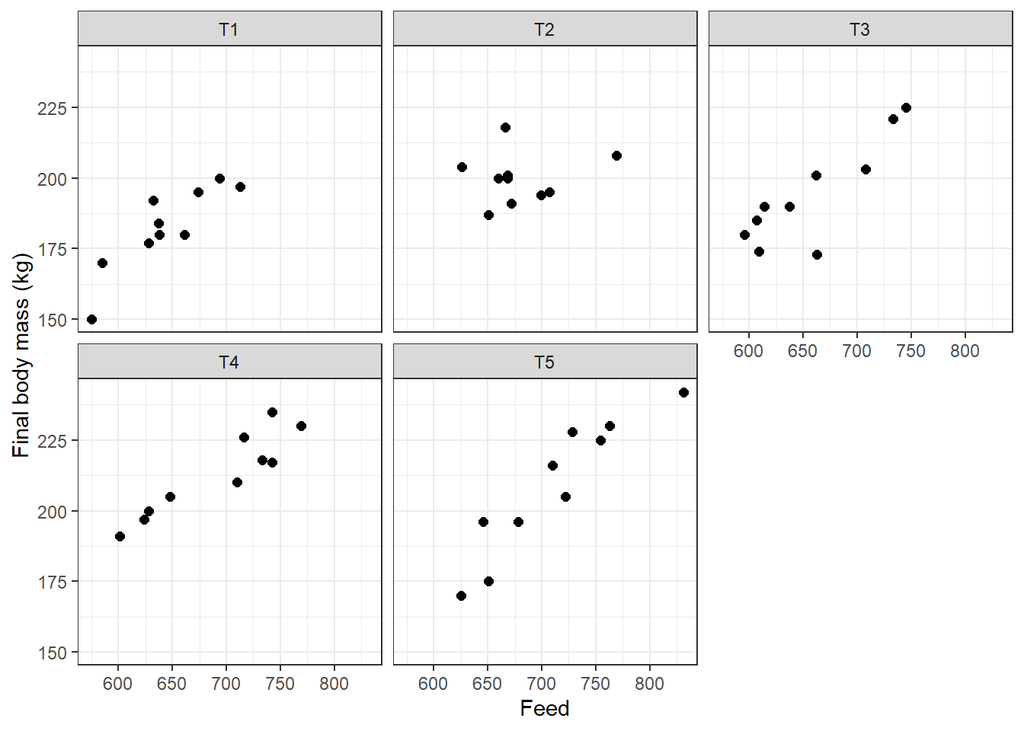

```r
dat |>
  ggplot(aes(x = feed, y = weight2)) +
  geom_point(size = 2) +
  labs(x = "Feed",
       y = "Final body mass (kg)") +
  facet_wrap(~treatment) +
  theme_bw()
```

# Legends

## Boxplots

The default legend of a boxplot is ugly. The shapes are not reactangles, but tiny boxplots. This is an easy way to prevent this:

```r
dat |>
  ggplot(aes(x = treatment, y = weight2, fill = treatment)) +
  geom_boxplot() +
  scale_x_discrete(labels = c("A", "B", "C", "D", "E")) +
  scale_fill_viridis(discrete = TRUE) +
  labs(x = "Treatment",
       y = "Final body mass (kg)",
       fill = "Treatment") +
  my_theme +
  guides(fill = guide_legend(override.aes = list(linetype = 0, size  = 5)))
```

[output not shown]

[output not shown]

## Single legend

In this case we want to colour the points and also use different shapes. Without the trick, two legends would be shown. Matching title ensures a single legend.

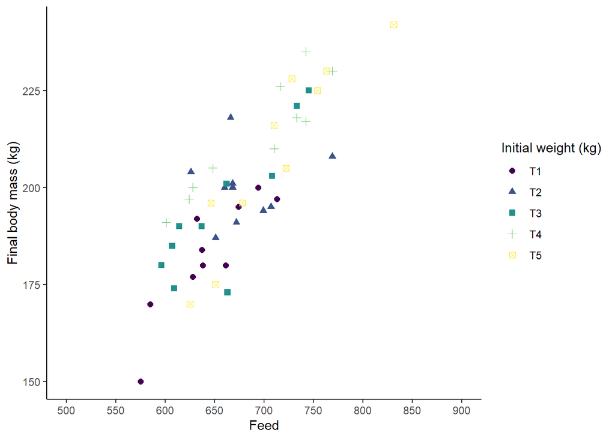

```r
dat |>
  ggplot(aes(x = feed, y = weight2, col = treatment, shape = treatment)) +
  geom_point(size = 2) +
  scale_x_continuous(limits=c(500, 900),
                     breaks = seq(500,900,50)) +
  scale_colour_viridis(discrete = TRUE) +
  labs(x = "Feed",
       y = "Final body mass (kg)",
       col = "Initial weight (kg)",
       shape = "Initial weight (kg)") +
  theme_classic()
```

# Define custom theme

Creating a custom ggplot2 theme allows you to control the overall appearance of your plots, ensuring consistency across multiple visualizations. When defining your own theme, you can adjust several components to tailor the plot’s style.

```r
my_theme = theme_classic() +
  theme(text = element_text(family = "sans"),
        plot.title   = element_text(face = "plain", size = 16),
        axis.title   = element_text(face = "bold", size = 16),
        axis.text    = element_text(size = 14, angle = 0, vjust = 0.5),
        legend.title = element_text(face = "bold", size = 16),
        legend.text  = element_text(face = "plain", size = 16),
        strip.text   = element_text(size = 16),
        legend.position = "top",
        panel.grid.major = element_blank(),
        panel.grid.minor = element_blank())
```

Now we apply this own theme to a plot:

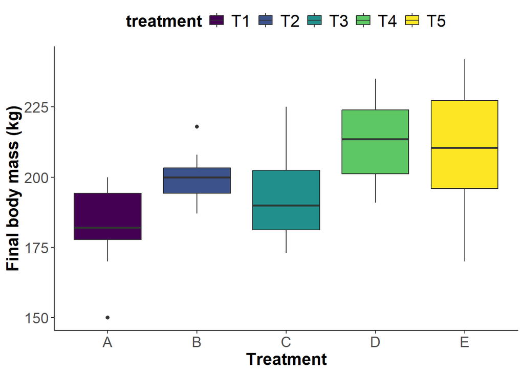

```r
dat |>
  ggplot(aes(x = treatment, y = weight2, fill = treatment)) +
  geom_boxplot() +
  scale_x_discrete(labels = c("A", "B", "C", "D", "E")) +
  scale_fill_viridis(discrete = TRUE) +
  labs(x = "Treatment",
       y = "Final body mass (kg)") +
  my_theme
```

# Combining plots with patchwork

The patchwork package is a powerful and flexible tool for combining multiple ggplots into a single layout. It is simple to use and provides a variety of options to control the arrangement of plots.

```r
p1 <- dat |>
  dplyr::filter(treatment == "T1") |>
  ggplot(aes(x = feed, y = weight2, col = weight1)) +
  geom_point(size = 2) +
  scale_x_continuous(limits=c(500, 900),
                     breaks = seq(500,900,50)) +
  scale_colour_viridis(discrete = FALSE, guide = "none") +
  labs(x = "Feed",
       y = "Final body mass (kg)",
       col = "Initial weight (kg)") +
  theme_classic()

p2 <- dat |>
  dplyr::filter(treatment == "T2") |>
  ggplot(aes(x = feed, y = weight2, col = weight1)) +
  geom_point(size = 2) +
  scale_x_continuous(limits=c(500, 900),
                     breaks = seq(500,900,50)) +
  scale_colour_viridis(discrete = FALSE, guide = "none") +
  labs(x = "Feed",
       y = "Final body mass (kg)",
       col = "Initial weight (kg)") +
  theme_classic()

p3 <- dat |>
  dplyr::filter(treatment == "T3") |>
  ggplot(aes(x = feed, y = weight2, col = weight1)) +
  geom_point(size = 2) +
  scale_x_continuous(limits=c(500, 900),
                     breaks = seq(500,900,50)) +
  scale_colour_viridis(discrete = FALSE, guide = "none") +
  labs(x = "Feed",
       y = "Final body mass (kg)",
       col = "Initial weight (kg)") +
  theme_classic()

p4 <- dat |>
  dplyr::filter(treatment == "T4") |>
  ggplot(aes(x = feed, y = weight2, col = weight1)) +
  geom_point(size = 2) +
  scale_x_continuous(limits=c(500, 900),
                     breaks = seq(500,900,50)) +
  scale_colour_viridis(discrete = FALSE, guide = "none") +
  labs(x = "Feed",
       y = "Final body mass (kg)",
       col = "Initial weight (kg)") +
  theme_classic()
```

```r
combined <- p1 + p2 + p3 + p4 +
  plot_layout(ncol = 2, guides = "collect") +
  scale_colour_viridis(discrete = FALSE) +
  plot_annotation(tag_levels = 'A') &
  theme(plot.tag = element_text(face = "bold", size = 20),
        legend.position = "bottom",
        legend.direction = "horizontal")
```

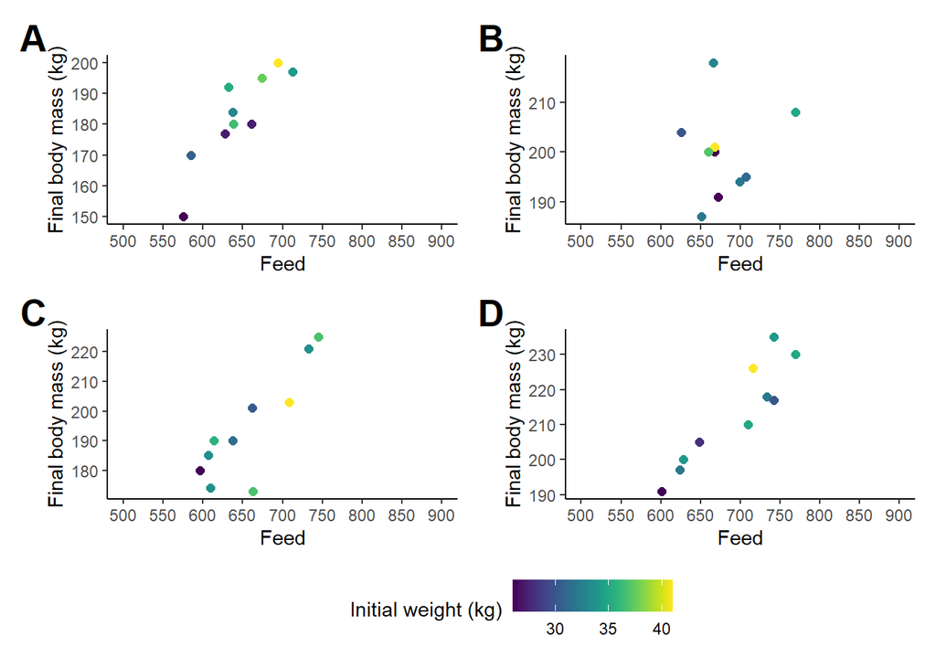

```r
combined
```

# Save plots

```r
ggsave("plot.png", plot = combined,
       width = 300, height = 300, units = "mm",
       dpi = 600)
```

```r
png("figure.png",
     width = 300, height = 300, units = "mm",
     pointsize = 10, res = 600)

combined

dev.off()
```

# How to cite R

“All analyses were performed using R Statistical Software (version 4.4.2; R Core Team 2024)”.

Reference: R Core Team (2024). R: A language and environment for statistical computing. R Foundation for Statistical Computing, Vienna, Austria. URL https://www.R-project.org/.

```r
citation()
```

```
  R Core Team (2024). _R: A Language and Environment for Statistical
  Computing_. R Foundation for Statistical Computing, Vienna, Austria.
  <https://www.R-project.org/>.

Ein BibTeX-Eintrag für LaTeX-Benutzer ist

  @Manual{,
    title = {R: A Language and Environment for Statistical Computing},
    author = {{R Core Team}},
    organization = {R Foundation for Statistical Computing},
    address = {Vienna, Austria},
    year = {2024},
    url = {https://www.R-project.org/},
  }

We have invested a lot of time and effort in creating R, please cite it
when using it for data analysis. See also 'citation("pkgname")' for
citing R packages.
```

```r
version$version.string
```

```
[1] "R version 4.4.2 (2024-10-31 ucrt)"
```

```r
citation("tidyverse")
```

```
Um Paket 'tidyverse' in Publikationen zu zitieren, nutzen Sie bitte:

  Wickham H, Averick M, Bryan J, Chang W, McGowan LD, François R,
  Grolemund G, Hayes A, Henry L, Hester J, Kuhn M, Pedersen TL, Miller
  E, Bache SM, Müller K, Ooms J, Robinson D, Seidel DP, Spinu V,
  Takahashi K, Vaughan D, Wilke C, Woo K, Yutani H (2019). "Welcome to
  the tidyverse." _Journal of Open Source Software_, *4*(43), 1686.
  doi:10.21105/joss.01686 <https://doi.org/10.21105/joss.01686>.

Ein BibTeX-Eintrag für LaTeX-Benutzer ist

  @Article{,
    title = {Welcome to the {tidyverse}},
    author = {Hadley Wickham and Mara Averick and Jennifer Bryan and Winston Chang and Lucy D'Agostino McGowan and Romain François and Garrett Grolemund and Alex Hayes and Lionel Henry and Jim Hester and Max Kuhn and Thomas Lin Pedersen and Evan Miller and Stephan Milton Bache and Kirill Müller and …
    year = {2019},
    journal = {Journal of Open Source Software},
    volume = {4},
    number = {43},
    pages = {1686},
    doi = {10.21105/joss.01686},
  }
```

```r
citation("viridis")
```

```
  Simon Garnier, Noam Ross, Robert Rudis, Antônio P. Camargo, Marco
  Sciaini, and Cédric Scherer (2024). viridis(Lite) -
  Colorblind-Friendly Color Maps for R. viridis package version 0.6.5.

Ein BibTeX-Eintrag für LaTeX-Benutzer ist

  @Manual{,
    title = {{viridis(Lite)} - Colorblind-Friendly Color Maps for R},
    author = {{Garnier} and {Simon} and {Ross} and {Noam} and {Rudis} and {Robert} and {Camargo} and Antônio Pedro and {Sciaini} and {Marco} and {Scherer} and {Cédric}},
    year = {2024},
    note = {viridis package version 0.6.5},
    url = {https://sjmgarnier.github.io/viridis/},
    doi = {10.5281/zenodo.4679423},
  }
```

```r
citation("patchwork")
```

```
Um Paket 'patchwork' in Publikationen zu zitieren, nutzen Sie bitte:

  Pedersen T (2024). _patchwork: The Composer of Plots_. R package
  version 1.3.0, <https://CRAN.R-project.org/package=patchwork>.

Ein BibTeX-Eintrag für LaTeX-Benutzer ist

  @Manual{,
    title = {patchwork: The Composer of Plots},
    author = {Thomas Lin Pedersen},
    year = {2024},
    note = {R package version 1.3.0},
    url = {https://CRAN.R-project.org/package=patchwork},
  }
```

```r
citation("agridat")
```

```
Um Paket 'agridat' in Publikationen zu zitieren, nutzen Sie bitte:

  Wright K (2024). _agridat: Agricultural Datasets_. R package version
  1.24, <https://CRAN.R-project.org/package=agridat>.

Ein BibTeX-Eintrag für LaTeX-Benutzer ist

  @Manual{,
    title = {agridat: Agricultural Datasets},
    author = {Kevin Wright},
    year = {2024},
    note = {R package version 1.24},
    url = {https://CRAN.R-project.org/package=agridat},
  }
```